# CSP 571 - Data Preparation & Analysis

Avinash Vellineni

Problem 2.1:

Loading Iris Dataset :

```r
data(iris) #Loading the inbuilt Iris dataset
head(iris) #Printing first 6 observations.
```

|  | Sepal.Length | Sepal.Width | Petal.Length | Petal.Width | Species |
| --- | --- | --- | --- | --- | --- |
| 1 | 5.1 | 3.5 | 1.4 | 0.2 | setosa |
| 2 | 4.9 | 3.0 | 1.4 | 0.2 | setosa |
| 3 | 4.7 | 3.2 | 1.3 | 0.2 | setosa |
| 4 | 4.6 | 3.1 | 1.5 | 0.2 | setosa |
| 5 | 5.0 | 3.6 | 1.4 | 0.2 | setosa |
| 6 | 5.4 | 3.9 | 1.7 | 0.4 | setosa |

Boxplot of each of the 4 features :

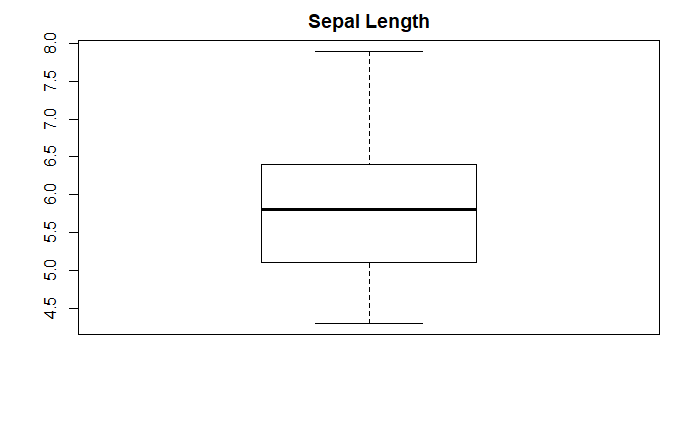

```r
boxplot(iris$Sepal.Length,data=iris,main="Sepal Length")
```

```r
print(IQR(iris$Sepal.Length))
```

```
[1] 1.3
```

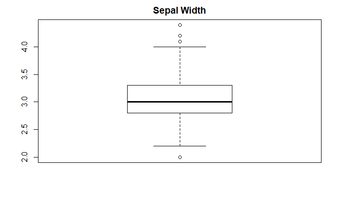

```r
boxplot(iris$Sepal.Width,data=iris,main="Sepal Width")
```

```r
print(IQR(iris$Sepal.Width))
```

```
[1] 0.5
```

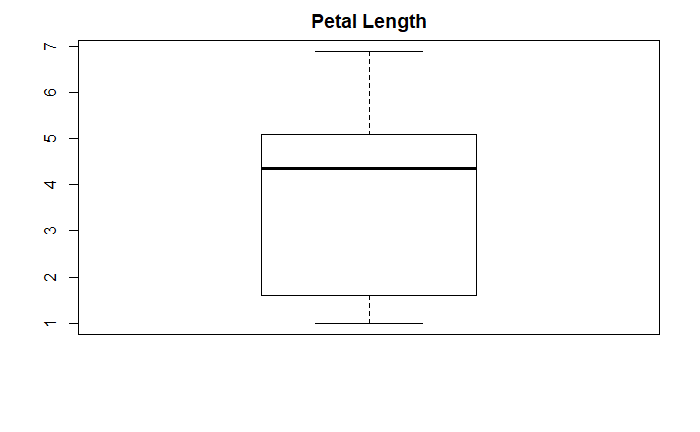

```r
boxplot(iris$Petal.Length,data=iris,main="Petal Length")
```

```r
print(IQR(iris$Petal.Length))
```

```
[1] 3.5
```

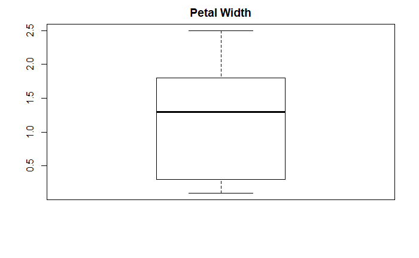

```r
boxplot(iris$Petal.Width,data=iris,main="Petal Width")
```

```r
print(IQR(iris$Petal.Width))
```

```
[1] 1.5
```

Conclusion : Petal length has the largest IQR among 4 features.

Standard Deviation for four Features:

```r
print(sd(iris$Sepal.Length,na.rm = F))
```

```
[1] 0.8280661
```

```r
print(sd(iris$Sepal.Width,na.rm = F))
```

```
[1] 0.4358663
```

```r
print(sd(iris$Petal.Length,na.rm = F))
```

```
[1] 1.765298
```

```r
print(sd(iris$Petal.Width,na.rm = F))
```

```
[1] 0.7622377
```

Yes the results from the standard deviation for the four features agree with the empirical values.

Colored boxplot for four features using ggplot2 library.

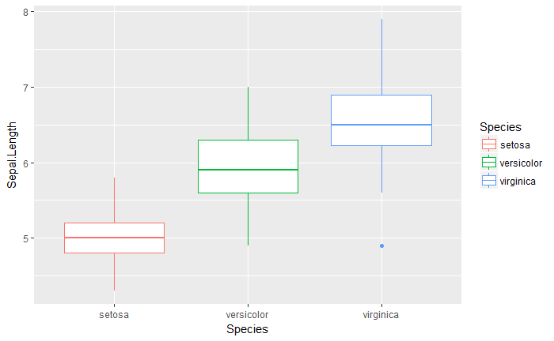

```r
library(tidyverse)
ggplot(data = iris) + geom_boxplot(mapping = aes(x = Species, y = Sepal.Length, color = Species))
```

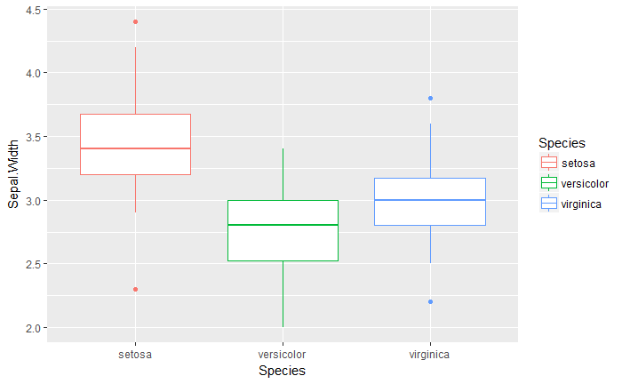

```r
ggplot(data = iris) + geom_boxplot(mapping = aes(x = Species, y = Sepal.Width, color = Species))
```

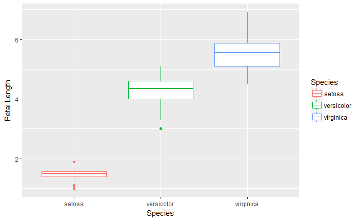

```r
ggplot(data = iris) + geom_boxplot(mapping = aes(x = Species, y = Petal.Length, color = Species))
```

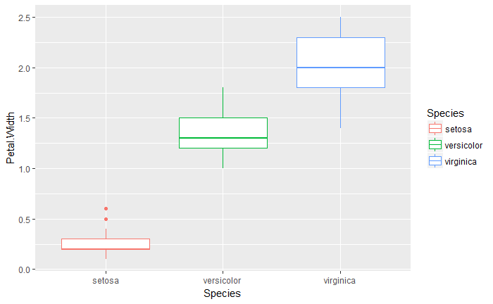

```r
ggplot(data = iris) + geom_boxplot(mapping = aes(x = Species, y = Petal.Width, color = Species))
```

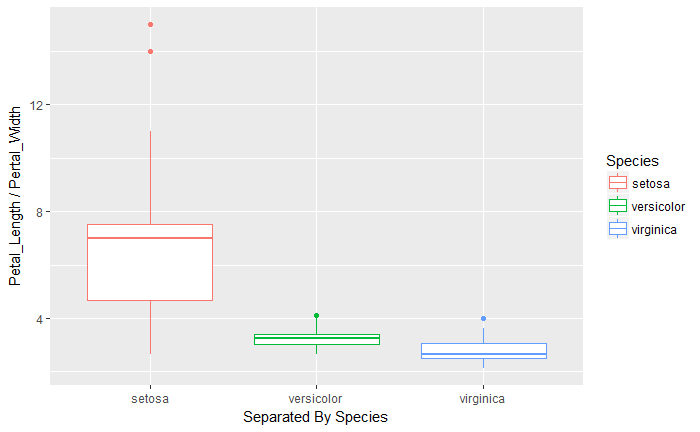

```r
ggplot(data = iris) + geom_boxplot(mapping = aes(x= Species,y = iris$Petal.Length/iris$Petal.Width, color = Species)) + labs(x="Separated By Species",y="Petal_Length / Pertal_Width")
```

Flower Type “Setosa” exhibits a significantly different PetalLength/Width once it is separated from the other classes.

Problem 2.2:

Loading the tree dataset and summary of each features:

```r
data(trees)
summary(trees)
```

```
     Girth           Height       Volume
 Min.   : 8.30   Min.   :63   Min.   :10.20
 1st Qu.:11.05   1st Qu.:72   1st Qu.:19.40
 Median :12.90   Median :76   Median :24.20
 Mean   :13.25   Mean   :76   Mean   :30.17
 3rd Qu.:15.25   3rd Qu.:80   3rd Qu.:37.30
 Max.   :20.60   Max.   :87   Max.   :77.00
```

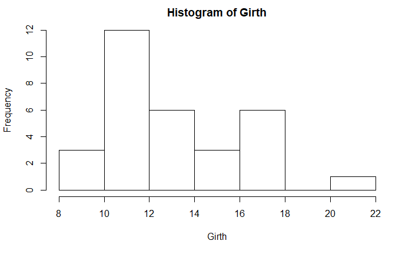

```r
#Right skewed
hist(trees$Girth,xlab = "Girth",ylab = "Frequency",main="Histogram of Girth")
```

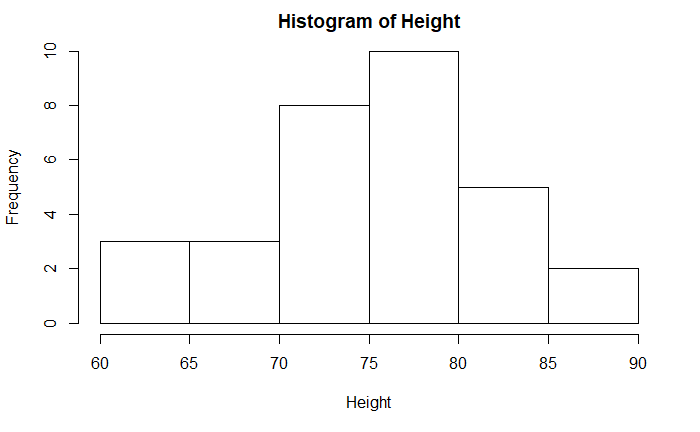

```r
#normal skewed
hist(trees$Height,xlab = "Height",ylab = "Frequency",main="Histogram of Height")
```

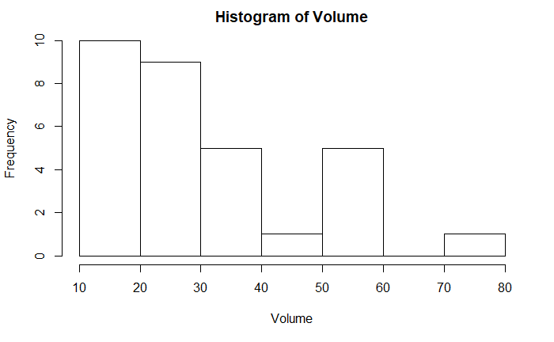

```r
#Right skewed
hist(trees$Volume,xlab = "Volume",ylab = "Frequency",main="Histogram of Volume")
```

“Height” feature in tree dataset appears to be normally distributed based on visual inspection.

```r
library(moments)
skewness(trees$Girth)
```

```
[1] 0.5263163
```

```r
skewness(trees$Height)
```

```
[1] -0.374869
```

```r
skewness(trees$Volume)
```

```
[1] 1.064357
```

Variables -> “Grith” and “Volume” are positively skewed.

Variable -> “Height” is negatively skewed.

Yes the results agree with the visual inspection.But on visual inspection the Feature “Height” appears to be normally distributed but it is slightly negatively skewed based on the observed skewness values for all the variables.

Problem 2.3:

Loading the auto-mpg dataset from the uci machine learning repository.

```r
url_auto_mpg <- "https://archive.ics.uci.edu/ml/machine-learning-databases/auto-mpg/auto-mpg.data"
data_auto_mpg <- read.csv(url_auto_mpg,as.is = F,sep="",header = T)
head(data_auto_mpg) # first six observations in the auto-mpg dataset.
```

|  | X18.0 | X8 | X307.0 | X130.0 | X3504. | X12.0 | X70 | X1 | chevrolet.chevelle.malibu |
| --- | --- | --- | --- | --- | --- | --- | --- | --- | --- |
| 1 | 15 | 8 | 350 | 165.0 | 3693 | 11.5 | 70 | 1 | buick skylark 320 |
| 2 | 18 | 8 | 318 | 150.0 | 3436 | 11.0 | 70 | 1 | plymouth satellite |
| 3 | 16 | 8 | 304 | 150.0 | 3433 | 12.0 | 70 | 1 | amc rebel sst |
| 4 | 17 | 8 | 302 | 140.0 | 3449 | 10.5 | 70 | 1 | ford torino |
| 5 | 15 | 8 | 429 | 198.0 | 4341 | 10.0 | 70 | 1 | ford galaxie 500 |
| 6 | 14 | 8 | 454 | 220.0 | 4354 | 9.0 | 70 | 1 | chevrolet impala |

Using as.numeric casting function to obtain the column “Horsepower”(X130.0) as a numeric vector, and replacing all NA values with the median.

```r
data_auto_mpg$X130.0<- suppressWarnings(as.numeric(as.character(data_auto_mpg$X130.0)))
median_value <- median(data_auto_mpg$X130.0,na.rm = T)
median_value
```

```
[1] 93
```

Original mean excluding NA Values:

```r
original_mean_exclude_na <- mean(dataauto$X130.0,na.rm = TRUE)
original_mean_exclude_na
```

```
[1] 104.4041
```

Replacing NA values with the median in the “Horsepower” Feature

```r
data_auto_mpg$X130.0[which(is.na(data_auto_mpg$X130.0))] <- median_value
```

New Mean after repacing NA values with the median:

```r
New_mean <- mean(data_auto_mpg$X130.0)
New_mean
```

```
[1] 104.2317
```

```r
Difference <- original_mean_exclude_na - New_mean
Difference
```

```
[1] 0.172354
```

Since the difference between the original and the new mean is 0.17 its very small.So we dont have much of an effect when the records with the NA values were ignored.